# Brahmin left versus merchant right: Changing political cleavages in 21 western democracies, 1948–2020

[QJE, February 2022](https://doi.org/10.1093/qje/qjab036)

Amory Gethin, Clara Martinez-Toledano, Thomas Piketty

2022年02月22日 11:54

# 要約

保守と革新の政治的分断が拡がっている。政治活動の需要と供給にどのような変化があるのか検証する。

- 政治需要と政治供給の連結データ: 21カ国(西欧+北米+ANZ)の選挙出口調査、得票、政党公約
- 革新政党需要(支持者の特徴): 学歴軸と所得軸
  - 低所得、近年は高所得も増、時間とともに高学歴化
- 供給(政党の公約): 経済分配軸と社会文化軸
  - 革新: 平等、環境[New!]、多元主義
  - 保守: 自由市場、伝統、反移民[New!]
  - 社会文化軸の差違が激化
- 各国別の叙述研究(単行本)をベースにデータ分析を加えて論文的にまとめたもの

# 背景

政治的分断が進んだ

- 環境問題顕著化と対立
- 反エスタブリッシュメント権威主義やポピュリズム(トランプ、Brexit、ル・ペンなど)の興隆

対立軸は何か、いつ始まったのか、西欧社会に共通か?

# 既存研究

本研究: 長期+包括的データ  
一要因では説明つかない  
高学歴の革新志向が60年代から開始 グローバライゼーションと貿易自由化、経済不安や失業、移民、文化や道徳的摩擦に着目

学歴による分断が進んだので、経済格差が広がっても再分配志向にならない 複数軸での政治競争: 他軸の分断が激しいほど再分配への支持は弱まる

所得と学歴を同時に分析  
所得と学歴の投票行動に与える効果が弱まっていることを提示  
複数の複雑な政策課題が意識されるようになって、所得ではなく学歴の違いが投票行動を変えている可能性 政治学の投票要因研究: green/alternative/libertarian vs. traditional/authoritarian/nationalist

# データ

- 得票データ: 1948-2020、300以上選挙、21カ国
- 出口調査(national election studies): 標本サイズ2000-4000、3カ国はEurobarometer, European Social Survey, European Election Studies
- マニフェスト(Comparative Manifesto Project database)

標準化: 各国の学制や所得区分の違いに対処 所得と学歴のbracket $\rightarrow$ percentileへの変換

- 各percentileのbracket構成比率で加重平均

出口調査は正確なのでウェイトの影響はあまりないとのこと 出口調査での投票先と選挙結果を合致させるようにサンプルウェイトを計算

- 解釈: 投票者の代表的サンプル

政党分類と出口調査での投票者の自己申告と整合的  
政党分類と公約は整合的  
自由民主主義政党の革新への分類でも結果は頑健 各政党の保守・革新への分類

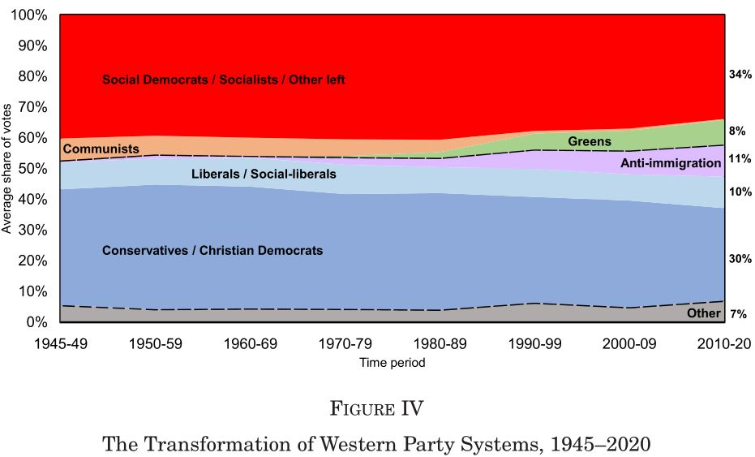

- 保守: 保守主義、キリスト教民主主義、反移民主義 [共和党(米)、保守党(英)、自由民主党(英、独)など]
- 革新: 社会民主主義、社会主義、共産主義 [民主党(米)、労働党(英)、緑の党など]

公約を擬文章化、内容分類(「社会正義」「法と秩序」「移民」など)

- 経済-分配スコア(右スコア): 自由市場賛成比率-再分配賛成比率
- 社会文化スコア(左スコア): 革新比率-保守比率
  - 保守: 政治的権威への賛同、伝統的道徳観への賛同、多文化主義への反対

# 推計

# 結果

## 需要: 投票行動

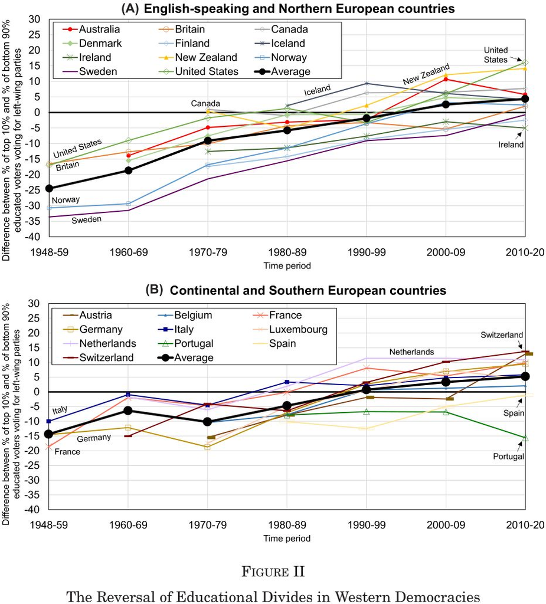

$\alpha^{T}_{ct}=\alpha^{T}_{t}, \beta^{T}_{ct}=\beta^{T}_{t}$を課した場合。

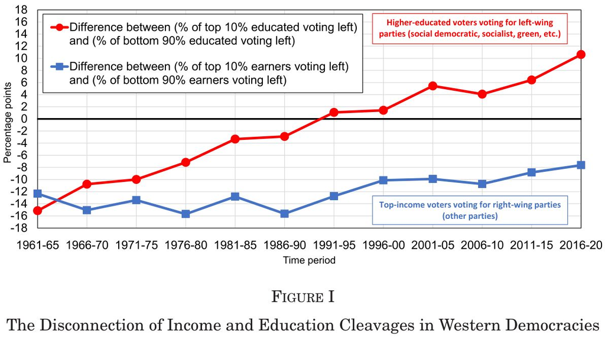

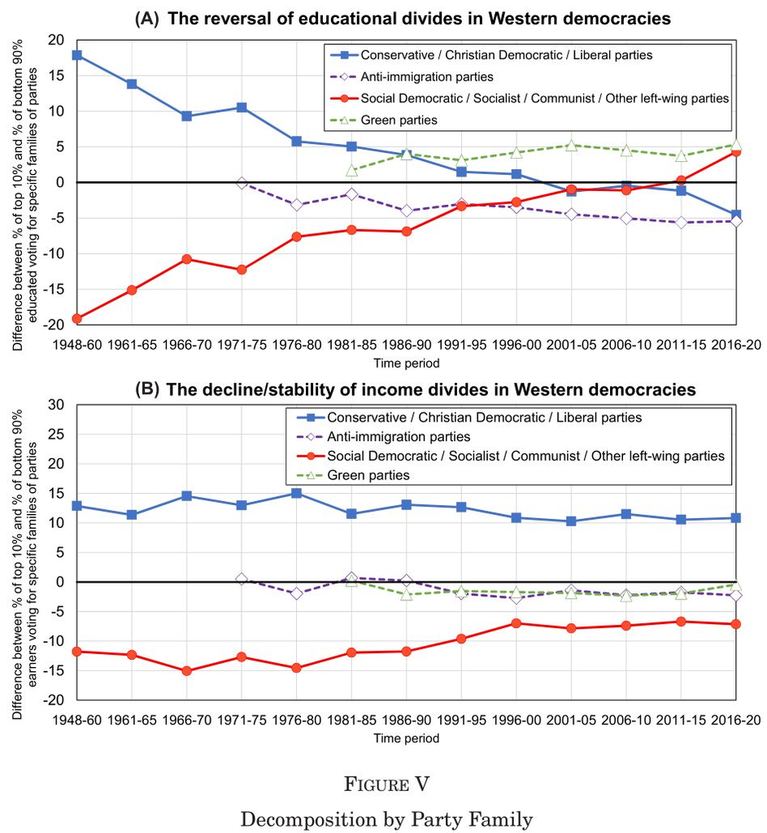

高学歴者と高所得者の各政党支持

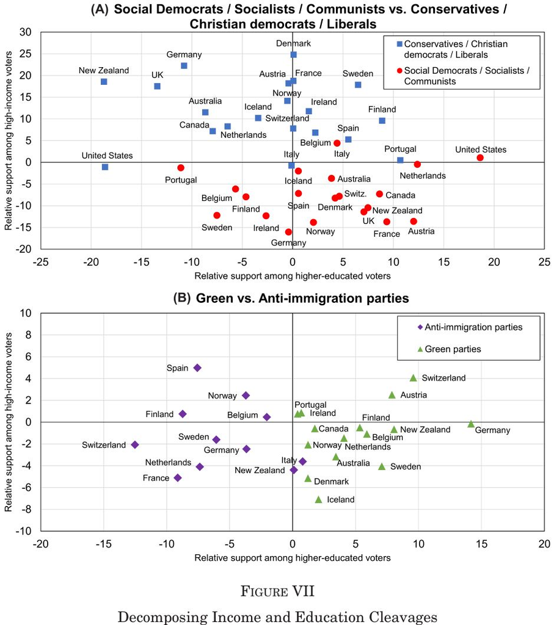

政党: 階級(エリートvs.非エリート)ベースから多元エリート(所得エリート、学歴エリート)ベースに変化した

## 供給: 公約

社会文化での亀裂  
保守: 国民生活、法と秩序、多文化主義の否定が多数  
革新: 環境、反成長が多数

経済-分配での亀裂  
保守: 自由市場、福祉国家の制限が多数  
革新: 福祉、平等、社会正義が多数

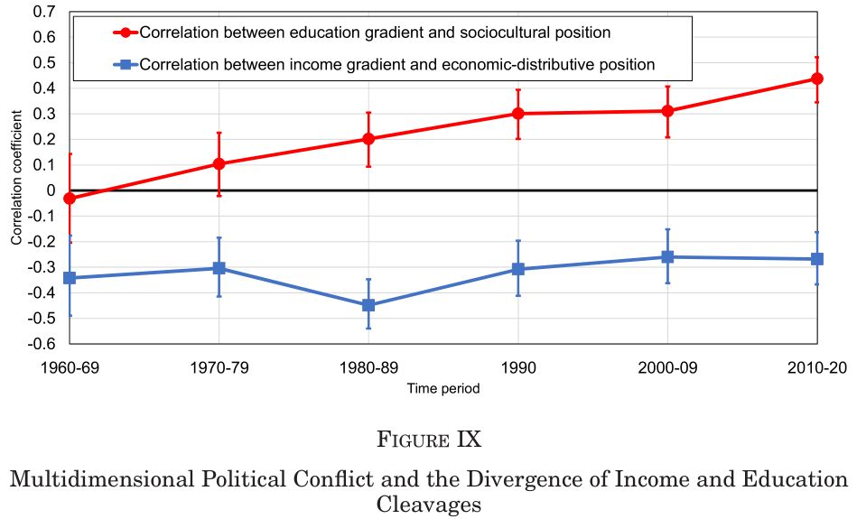

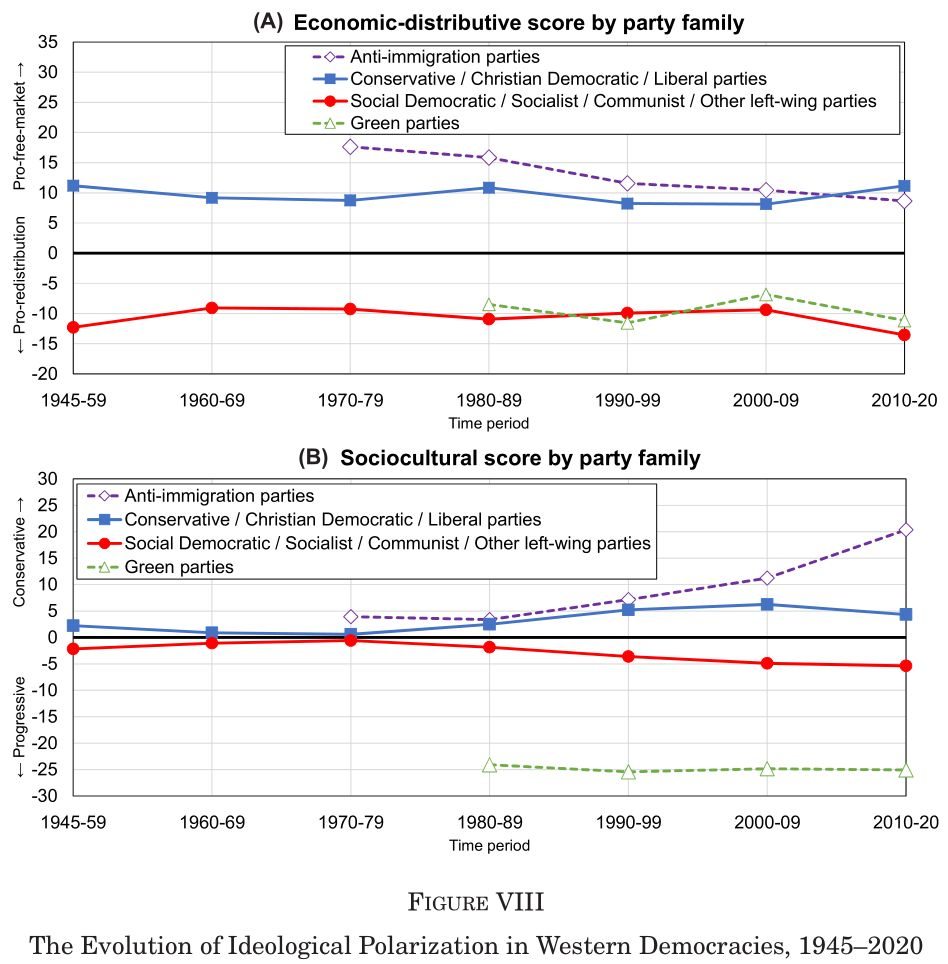

旧政党: 経済-分配スコアは不変、社会文化スコアが僅かに極端化

- 需要側のincome gradientは不変、education gradientが上昇したことに供給側が対応、と解釈
- 各党ごとの高所得者投票率と経済-分配スコアの相関は負値で不変、高学歴者投票率と社会文化スコアの相関は負値から正値に変化(Fig IX)

新政党: 極端な社会文化を訴える、反移民党が極端化

$\Rightarrow$ *社会文化で極端化の兆しはあるが、反移民党を除いて政治的分断が進行したように見えない*

# その他

高学歴の革新志向: 共変数、世代、宗教の関係

$$y_{1}
=
b_{1}x_{1}+e_{2}, \quad
y_{2}
=
b_{2}x_{2}+e_{2}$$
期待値をとって
$$E[y_{1}]-E[y_{2}]
=
b_{1}E[x_{1}]-b_{2}E[x_{2}]+b_{1}E[x_{2}]-b_{1}E[x_{2}],\\$$
$$\phantom{E[y_{1}]-E[y_{2}]}
=
\underbrace{b_{1}\left(E[x_{1}]-E[x_{2}]\right)}_{\Delta\mbox{covariate mean}}+\underbrace{(b_{1}-b_{2})E[x_{2}]}_{\mbox{unexplained}}.$$

- 共変数を加えて推計すると共変数の貢献は16%
- Kitagawa-Oaxaca-Blinder decompositionでも共変数の貢献は17%
- 老年世代ほど低学歴者が革新志向、若年世代ほど高学歴者が革新志向
- 世代や宗教ごとの投票行動変化はない

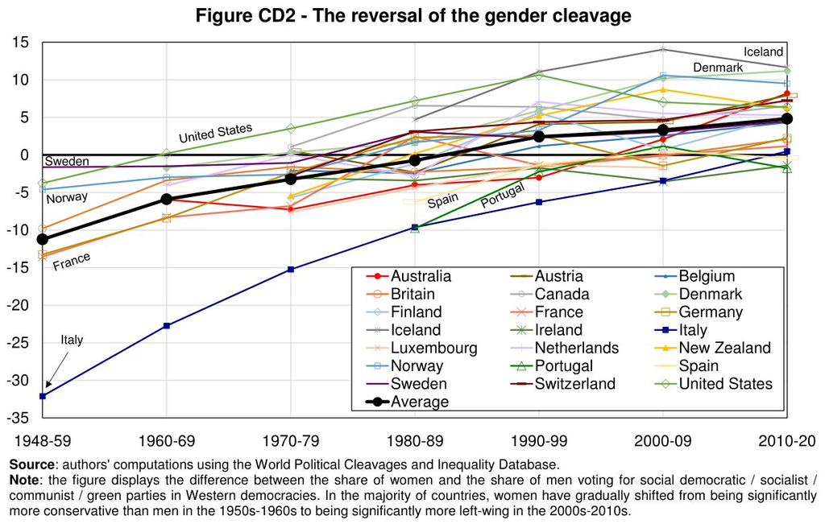

女性の革新投票率-男性の革新投票率

女性は男性よりも革新志向を強めている(Fig CD2)

- 宗教: 昔は男性よりも女性が信仰心があったので保守的
- 学歴: 女性も学歴が伸びたので革新志向を強めた
- しかし、宗教や学歴を制御しても、女性は男性よりも革新志向を強めている

# 結論

戦後数十年間の政党支持は低所得・低学歴が革新、高所得・高学歴が保守だった

高学歴者が革新志向を強めた

*低学歴者($\simeq$低所得者)が社会文化において保守志向を強めた…強調されず*

政党間の社会文化競争が激化し、学歴の違いで支持政党が説明できるようになった

- *因果関係が理解不能*

以前は低所得者=低学歴者が再配分を求めたが、今は非高所得者にも高学歴者がいるため、非高所得者が団結して再配分を求めない、経済格差が再配分に結びついていない、と考えられる

- *説明不足なので理解不能*

留保

- 政党の保守/革新分類は不正確
- 高学歴の革新志向を生んだメカニズムは不明
  - 供給変化の因果関係を知る必要

# 感想

長所

- 視点がよい  
  政治分断を投票行動で判断し、長期間複数国で傾向を計測した。  
  政治活動を需要と供給に分解し、政治分断の原因を解釈した。
- 新たな発見とカジュアルな見解の実証  
  殆どの国で革新支持層の高学歴化  
  政党間で社会文化競争が激化  
  保守支持層は変わらず高所得者主体だが反移民で低学歴者を取り込む

短所

- 因果関係: なぜこうなる? (メカニズムがない)
- 当然?  
  革新支持者の高学歴化$\leftarrow$教育の普及  
  高所得者の保守支持$\leftarrow$税金や制約を逃れたい
- 2項分類したことで過度の単純化$\rightarrow$推計結果を歪める?  
  技術と制度次第で保守でも環境保護を訴えられるかも  
  経済-分配軸で移民に反対ではない保守に反移民を含めると、保守政党の変化にノイズが加わるかも  
  自由取引を志向する保守と内向きの反移民が合従連衡している現実が矛盾含みなのかも  
  労働組合系政党は競合労働者になる移民に寛容ではない

ピケティらしいbig picture研究  
論文のタイトルを何にすべきか分からない